# EAS 508 Assignment 2– Tejeswini Anjaneya Reddy UB ID-50606824

**Remark:**

- `Please change the file name when submitting your assignment`
- `Only .html file is allowed to submit, any other form will not be graded`
- `Any conclusions without evidence will be granted 0`
- `Academic integrity`

```r
library(ISLR2)
library(ggplot2)
library(MASS)
library(car)
library(class)
```

In case you need to write math expression, please use the quick tutorial as the reference: https://www1.cmc.edu/pages/faculty/aaksoy/latex/latexthree.html

# Question 1 [5 points]

Describe a situation or problem from your job, everyday life, current events, etc., for which a logistic regression model would be appropriate. List some (up to 5) predictors that you might use.

Please show your work.

```
Answer: Logistic regression model would be appropriate to predict if my family members will buy a drink in the morning. Listed below are the predictors I might use:
1) Time whether morning or late morning
2) Weather if cold or sunny
3) Distance to the cafe if near or far
4) Price of the Drink
5) Sleep duration
```

# Question 2 [20 points]

In this problem, we will use the Naive Bayes algorithm to fit a spam filter by hand. This question does not involve any programming but only derivation and hand calculation. Spam filters are used in all email services to classify received emails as “Spam” or “Not Spam”. A simple approach involves maintaining a vocabulary of words that commonly occur in “Spam” emails and classifying an email as “Spam” if the number of words from the dictionary that are present in the email is over a certain threshold. We are given the vocabulary consists of 15 words

$$V = {\text{secret, offer, low, price,
valued, customer, today, dollar, million, sports, is, for, play,
healthy, pizza}}.$$

We will use $V_i$ to represent the $i$th word in $V$ . As our training dataset, we are also given 3 example spam messages,

- million dollar offer for today
- secret offer today
- secret is secret

and 4 example non-spam messages

- low price for valued customer
- play secret sports today
- sports is healthy
- low price pizza

Recall that the Naive Bayes classifier assumes the probability of an input depends on its input feature. The feature for each sample is defined as $x^{(i)}=[x^{(i)}_1, x^{(i)}_2,\cdots, x^{(i)}_p], i=1,\cdots,m$ and the class of the $i$th sample is $y^{(i)}$. In our case the length of the input vector is $p= 15$, which is equal to the number of words in the vocabulary $V$ (hint: recall that how did we define a dummy variable). Each entry $x^{(i)}_j$ is equal to the number of times word $V_j$ occurs in the $i$-th message.

1.[5 points] Calculate class prior $P(y = 0)$ and $P(y = 1)$ from the training data, where $y=0$ corresponds to spam messages, and $y=1$ corresponds to non-spam messages. Note that these class prior essentially corresponds to the frequency of each class in the training sample. Write down the predictor vectors for each spam and non-spam messages.

```
Answer: Class Priors are below:
```

Class Prior of P(y=0) or Probability of spam messages:

$$P(y=0)=\frac{\text{Number of spam messages}}{\text{Total count of
messages}}=\frac{3}{7}$$

Class Prior of P(y=1) or Probability of non spam messages:

$$P(y=1)=\frac{\text{Number of non-spam messages}}{\text{Total count of
messages}}=\frac{4}{7}$$

```
        Predictor Vectors for each spam and non-spam messages are below:
```

Predictor Vectors for spam messages:

Predictor Vector for message ‘million dollar offer for today’:
$$\mathbf{x}^{(1)} = [0, 1, 0, 0, 0, 0, 1, 1, 1, 0, 0, 1, 0, 0, 0]$$
Predictor Vector for message ‘secret offer today’:
$$\mathbf{x}^{(2)} = [1, 1, 0, 0, 0, 0, 1, 0, 0, 0, 0, 0, 0, 0, 0]$$
Predictor Vector for message ‘secret is secret’
$$\mathbf{x}^{(3)} = [2, 0, 0, 0, 0, 0, 0, 0, 0, 0, 1, 0, 0, 0, 0]$$

Predictor Vectors for non-spam messages:

Predictor Vector for message ‘low price for valued customer’:
$$\mathbf{x}^{(4)} = [0, 0, 1, 1, 1, 1, 0, 0, 0, 0, 0, 1, 0, 0, 0]$$

Predictor Vector for message ‘play secret sports today’:
$$\mathbf{x}^{(5)} = [1, 0, 0, 0, 0, 0, 1, 0, 0, 1, 0, 0, 1, 0, 0]$$

Predictor Vector for message ‘sports is healthy’:
$$\mathbf{x}^{(6)} = [0, 0, 0, 0, 0, 0, 0, 0, 0, 1, 1, 0, 0, 1, 0]$$

Predictor Vector for message ‘low price pizza’:
$$\mathbf{x}^{(7)} = [0, 0, 1, 1, 0, 0, 0, 0, 0, 0, 0, 0, 0, 0, 1]$$

2. [15 points] In the Naive Bayes model, assuming the keywords are independent of each other (this is a simplification), the likelihood of a sentence with its feature vector $x$ given a class $c$ is given by
   $$P(x|y=c)=\prod_{i=1}^{15}P(x_i|y=c),
   c=\{0,1\}.$$

Given a test message “today is secret”, using the Naive Bayes classier to calculate the posterior and decide whether it is spam or not spam. Please show your work.

```
Answer: To determine whether below message is spam or not:
```

Message is ‘today is secret’ and its predictor vector is as follows:
$$\mathbf{x} = [1,0,0,0,0,0,1,0,0,0,1,0,0,0,0]$$

Total number of words in both spam and non-spam message:

Spam: 11 Non-Spam: 15

As we have computed the class priors earlier,
$$P(y=0)=\frac{3}{7} \space and\space P(y=1)=\frac{4}{7}$$

**Likelihood Calculations**

To compute the likelihood of the test message **“today is secret”** for both the spam and non-spam classes.

*For Spam Class $y = 0$:*

The likelihood of the test message given the spam class is:

$$P(x|y=0) = P(\text{today}|y=0) \times P(\text{is}|y=0) \times
P(\text{secret}|y=0)$$

From the word frequencies in the spam class:

- $P(\text{today} | y = 0) = \frac{2}{11}$
- $P(\text{is} | y = 0) = \frac{1}{11}$
- $P(\text{secret} | y = 0) = \frac{3}{11}$

So, the likelihood for spam is:

$$P(x|y = 0) = \frac{2}{11}\times\frac{1}{11}\times\frac{3}{11} =
\frac{6}{1331}$$

*For Non-Spam Class $y = 1$:*

The likelihood of the test message given the non-spam class is:

$$P(x|y = 1) = P(\text{today} | y=1)\times P(\text{is} | y=1) \times
P(\text{secret} | y = 1)$$

From the word frequencies in the non-spam class:

- $P(\text{today}|y = 1) = \frac{1}{15}$
- $P(\text{is}| y = 1) = \frac{1}{15}$
- $P(\text{secret}| y = 1) = \frac{1}{15}$

Hence, the likelihood for non-spam is:

$$P(x | y = 1) = \frac{1}{15} \times\frac{1}{15}\times \frac{1}{15} =
\frac{1}{3375}$$
` *Posterior Probabilities:*

1. *Posterior for $y = 0$ or Spam is*

   $$P(y = 0 \mid x) \propto P(x \mid y = 0)\cdot P(y = 0) = \frac{6}{1331}*
   \frac{3}{7}$$
   *Thus we get Posterior for $y = 0$ as 0.0019319*
2. *Posterior for $y = 1$ or non Spam is*

   $$P(y = 1 \mid x)\propto P(x \mid y = 1) \cdot P(y = 1) = \frac{1}{3375} *
   \frac{4}{7}$$

*Thus we will get Posterior for $y = 1$ as 0.0001693*

We can conclude that since $P(y = 0\mid x)$ is greater than $P(y = 1\mid x)$, we can classify the message “today is secret” as Spam.

# Question 3 [16 points]

The provided dataset is a subset of the public data from the 2022 EPA Automotive Trends Report. It will be used to study the effects of various vehicle characteristics on CO2 emissions. The dataset consists of a dataframe with 1703 observations with the following 7 variables:

- Model.Year: year the vehicle model was produced (quantitative)
- Type: vehicle type (qualitative)
- MPG: miles per gallon of fuel (quantitative)
- Weight: vehicle weight in lbs (quantitative)
- Horsepower: vehicle horsepower in HP (quantitative)
- Acceleration: acceleration time (from 0 to 60 mph) in seconds (quantitative)
- CO2: carbon dioxide emissions in g/mi (response variable)

(1).[3 points] Read the data, Fit a multiple linear regression model called model1 using CO2 as the response and all predicting variables. Using $\alpha=0.05$, which of the estimated coefficients that were statistically significant.

```
Answer:
```

```r
data <- read.csv("emissions.csv")
head(data,3)
```

```
##   Model.Year Type      MPG   Weight Horsepower Acceleration      CO2
## 1       2008  Van 20.39302 4500.000   241.8963       8.9064 435.7864
## 2       2009  Van 20.39440 4835.321   241.9881       9.0603 435.7570
## 3       2010  Van 20.17616 4840.431   244.0000       9.1116 440.4703
```

```r
data <- setNames(data, replace(names(data), names(data) == "Model.Year", "ModelYear"))

model1<- lm(CO2 ~ ModelYear+Type + MPG +Weight +Horsepower +Acceleration,data=data)

summary(model1)
```

```
##
## Call:
## lm(formula = CO2 ~ ModelYear + Type + MPG + Weight + Horsepower +
##     Acceleration, data = data)
##
## Residuals:
##     Min      1Q  Median      3Q     Max
## -49.969 -12.299  -4.040   6.126 242.173
##
## Coefficients:
##                Estimate Std. Error t value Pr(>|t|)
## (Intercept)   1.250e+03  2.983e+02   4.190 2.94e-05 ***
## ModelYear    -2.859e-01  1.525e-01  -1.875   0.0609 .
## TypeSUV      -1.594e+01  2.199e+00  -7.249 6.35e-13 ***
## TypeTruck    -1.802e+01  2.201e+00  -8.186 5.24e-16 ***
## TypeVan      -3.082e+01  2.397e+00 -12.854  < 2e-16 ***
## MPG          -1.749e+01  3.507e-01 -49.882  < 2e-16 ***
## Weight        4.978e-02  2.588e-03  19.235  < 2e-16 ***
## Horsepower   -3.460e-01  2.918e-02 -11.858  < 2e-16 ***
## Acceleration  1.333e+00  5.516e-01   2.417   0.0158 *
## ---
## Signif. codes:  0 '***' 0.001 '**' 0.01 '*' 0.05 '.' 0.1 ' ' 1
##
## Residual standard error: 23.3 on 1694 degrees of freedom
## Multiple R-squared:  0.9399, Adjusted R-squared:  0.9396
## F-statistic:  3309 on 8 and 1694 DF,  p-value: < 2.2e-16
```

```r
model1_summary<-summary(model1)
significant_vars<-model1_summary$coefficients[,"Pr(>|t|)"]<0.05
significant_coeffcients<-model1_summary$coefficients[significant_vars,]
print(significant_vars)
```

```
##  (Intercept)    ModelYear      TypeSUV    TypeTruck      TypeVan          MPG
##         TRUE        FALSE         TRUE         TRUE         TRUE         TRUE
##       Weight   Horsepower Acceleration
##         TRUE         TRUE         TRUE
```

```r
print(significant_coeffcients)
```

```
##                   Estimate   Std. Error    t value     Pr(>|t|)
## (Intercept)  1249.80675733 298.31053371   4.189617 2.938150e-05
## TypeSUV       -15.93840179   2.19865038  -7.249175 6.346588e-13
## TypeTruck     -18.01880554   2.20110001  -8.186273 5.239622e-16
## TypeVan       -30.81777417   2.39748753 -12.854196 3.757409e-36
## MPG           -17.49337704   0.35069496 -49.882032 0.000000e+00
## Weight          0.04977899   0.00258789  19.235359 9.777421e-75
## Horsepower     -0.34598063   0.02917594 -11.858423 3.219461e-31
## Acceleration    1.33301751   0.55158999   2.416682 1.576779e-02
```

**We can see that TypeSUV,TypeTruck,TypeVan,MPG,Weight,Horsepower and Acceleration predicting variables are statistically significant.**

(2).[2 points] Is the overall regression (model1) significant at an $\alpha$-level of $0.05$? Explain how you determined the answer.

```
Answer: As the p-value is 0 which is lesser than the alpha level 0.05, we can conclude that the overall regression model1 is significant:
```

```r
fstatistic <- model1_summary$fstatistic
fpvalue <- 1-pf(fstatistic[1], fstatistic[2], fstatistic[3])
print(fstatistic)
```

```
##    value    numdf    dendf
## 3309.246    8.000 1694.000
```

```r
print(fpvalue)
```

```
## value
##     0
```

(3).[6 points] **Identifying Influential Data Points** Cook’s Distances

The basic idea behind the measure is to delete the observations one at a time, each time refitting the regression model on the remaining $n-1$ observations. Then, we compare the results using all $n$ observations to the results with the $i$th observation deleted to see how much influence the observation has on the analysis. Analyzed as such, we are able to assess the potential impact each data point has on the regression analysis. One of such a method is called `Cook's distance`. To learn more on Cook’s distance in R, see https://rpubs.com/DragonflyStats/Cooks-Distance.

Create a plot for the Cook’s Distances (use model1). Using a threshold of $1$, are there any outliers? If yes, which data points?

```
Answer:
```

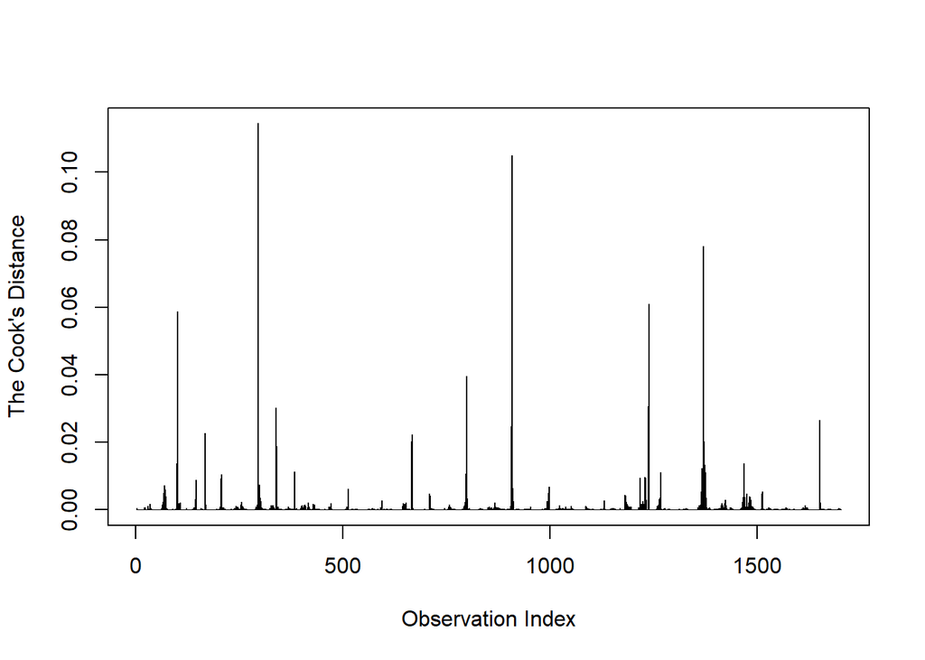

```r
cooks_dist<- cooks.distance(model1)
plot(cooks_dist, type = "h", ylab = "The Cook's Distance", xlab = "Observation Index")
abline(h = 1, col = "lightblue", lty = 3)
```

```r
which(cooks_dist > 1)
```

```
## named integer(0)
```

**Since there are no observations in the dataset as above output, this indicates that the model does not have any outliers.**

(4).[5 points] **Detecting Multicollinearity Using Variance Inflation Factors (VIF)**

The effects that multicollinearity can have on our regression analyses and subsequent conclusions, how can we tell if multicollinearity is present in our data? A variance inflation factor exists for each of the predictors in a multiple regression model. For example, the variance inflation factor for the estimated regression coefficient $\beta_j$—denoted $VIF_j$ —is just the factor by which the variance of $\beta_j$ is “inflated” by the existence of correlation among the predictor variables in the model.

A VIF of $1$ means that there is no correlation among the $j$th predictor and the remaining predictor variables, and hence the variance of $\beta_j$ is not inflated at all. The general rule of thumb is that VIFs exceeding $4$ warrant further investigation, while VIFs exceeding $10$ are signs of serious multicollinearity requiring correction. For more information, see https://search.r-project.org/CRAN/refmans/usdm/html/vif.html.

Calculate the VIF of each predictor (use model1). Using a threshold of $\max(10, \frac{1}{1-R^2})$ what conclusions can you make regarding multicollinearity?

```r
vifvalues <-vif(model1)
r_squared<- summary(model1)$r.squared
thresholds <- pmax(10, 1 /(1- r_squared))

high_vifpredictors <- vifvalues[vifvalues>thresholds]
high_vifpredictors
```

```
## numeric(0)
```

```
Since we got no predictors as above output which says there is no multicollinearity in predictors.
```

# Question 4 [16 points]

(1). Using the GermanCredit data set german.credit (Download the dataset from http://archive.ics.uci.edu/ml/datasets/Statlog+%28German+Credit+Data%29 and read the description), use logistic regression to find a good predictive model for whether credit applicants are good credit risks or not. Show your model (factors used and their coefficients), the output, and the quality of fit. You can use the glm function in R. To get a logistic regression (logit) model on data where the response is either zero or one, use family=binomial in your glm function call. Steps including:

a.[2 points] load the dataset

```
Answer:
```

```r
german_credit <-read.table("german.data",header = FALSE,sep = " ")
head(german_credit)
```

```
##    V1 V2  V3  V4   V5  V6  V7 V8  V9  V10 V11  V12 V13  V14  V15 V16  V17 V18
## 1 A11  6 A34 A43 1169 A65 A75  4 A93 A101   4 A121  67 A143 A152   2 A173   1
## 2 A12 48 A32 A43 5951 A61 A73  2 A92 A101   2 A121  22 A143 A152   1 A173   1
## 3 A14 12 A34 A46 2096 A61 A74  2 A93 A101   3 A121  49 A143 A152   1 A172   2
## 4 A11 42 A32 A42 7882 A61 A74  2 A93 A103   4 A122  45 A143 A153   1 A173   2
## 5 A11 24 A33 A40 4870 A61 A73  3 A93 A101   4 A124  53 A143 A153   2 A173   2
## 6 A14 36 A32 A46 9055 A65 A73  2 A93 A101   4 A124  35 A143 A153   1 A172   2
##    V19  V20 V21
## 1 A192 A201   1
## 2 A191 A201   2
## 3 A191 A201   1
## 4 A191 A201   1
## 5 A191 A201   2
## 6 A192 A201   1
```

```r
str(german_credit)
```

```
## 'data.frame':    1000 obs. of  21 variables:
##  $ V1 : chr  "A11" "A12" "A14" "A11" ...
##  $ V2 : int  6 48 12 42 24 36 24 36 12 30 ...
##  $ V3 : chr  "A34" "A32" "A34" "A32" ...
##  $ V4 : chr  "A43" "A43" "A46" "A42" ...
##  $ V5 : int  1169 5951 2096 7882 4870 9055 2835 6948 3059 5234 ...
##  $ V6 : chr  "A65" "A61" "A61" "A61" ...
##  $ V7 : chr  "A75" "A73" "A74" "A74" ...
##  $ V8 : int  4 2 2 2 3 2 3 2 2 4 ...
##  $ V9 : chr  "A93" "A92" "A93" "A93" ...
##  $ V10: chr  "A101" "A101" "A101" "A103" ...
##  $ V11: int  4 2 3 4 4 4 4 2 4 2 ...
##  $ V12: chr  "A121" "A121" "A121" "A122" ...
##  $ V13: int  67 22 49 45 53 35 53 35 61 28 ...
##  $ V14: chr  "A143" "A143" "A143" "A143" ...
##  $ V15: chr  "A152" "A152" "A152" "A153" ...
##  $ V16: int  2 1 1 1 2 1 1 1 1 2 ...
##  $ V17: chr  "A173" "A173" "A172" "A173" ...
##  $ V18: int  1 1 2 2 2 2 1 1 1 1 ...
##  $ V19: chr  "A192" "A191" "A191" "A191" ...
##  $ V20: chr  "A201" "A201" "A201" "A201" ...
##  $ V21: int  1 2 1 1 2 1 1 1 1 2 ...
```

b.[4 points] explore the dataset, including summary of dataset, types of predictors, if there are categorical predictors, convert the predictors to factors.

```
Answer:
```

```r
library(dplyr)
summary(german_credit)
```

```
##       V1                  V2            V3                 V4
##  Length:1000        Min.   : 4.0   Length:1000        Length:1000
##  Class :character   1st Qu.:12.0   Class :character   Class :character
##  Mode  :character   Median :18.0   Mode  :character   Mode  :character
##                     Mean   :20.9
##                     3rd Qu.:24.0
##                     Max.   :72.0
##        V5             V6                 V7                  V8
##  Min.   :  250   Length:1000        Length:1000        Min.   :1.000
##  1st Qu.: 1366   Class :character   Class :character   1st Qu.:2.000
##  Median : 2320   Mode  :character   Mode  :character   Median :3.000
##  Mean   : 3271                                         Mean   :2.973
##  3rd Qu.: 3972                                         3rd Qu.:4.000
##  Max.   :18424                                         Max.   :4.000
##       V9                V10                 V11            V12
##  Length:1000        Length:1000        Min.   :1.000   Length:1000
##  Class :character   Class :character   1st Qu.:2.000   Class :character
##  Mode  :character   Mode  :character   Median :3.000   Mode  :character
##                                        Mean   :2.845
##                                        3rd Qu.:4.000
##                                        Max.   :4.000
##       V13            V14                V15                 V16
##  Min.   :19.00   Length:1000        Length:1000        Min.   :1.000
##  1st Qu.:27.00   Class :character   Class :character   1st Qu.:1.000
##  Median :33.00   Mode  :character   Mode  :character   Median :1.000
##  Mean   :35.55                                         Mean   :1.407
##  3rd Qu.:42.00                                         3rd Qu.:2.000
##  Max.   :75.00                                         Max.   :4.000
##      V17                 V18            V19                V20
##  Length:1000        Min.   :1.000   Length:1000        Length:1000
##  Class :character   1st Qu.:1.000   Class :character   Class :character
##  Mode  :character   Median :1.000   Mode  :character   Mode  :character
##                     Mean   :1.155
##                     3rd Qu.:1.000
##                     Max.   :2.000
##       V21
##  Min.   :1.0
##  1st Qu.:1.0
##  Median :1.0
##  Mean   :1.3
##  3rd Qu.:2.0
##  Max.   :2.0
```

```r
str(german_credit)
```

```
## 'data.frame':    1000 obs. of  21 variables:
##  $ V1 : chr  "A11" "A12" "A14" "A11" ...
##  $ V2 : int  6 48 12 42 24 36 24 36 12 30 ...
##  $ V3 : chr  "A34" "A32" "A34" "A32" ...
##  $ V4 : chr  "A43" "A43" "A46" "A42" ...
##  $ V5 : int  1169 5951 2096 7882 4870 9055 2835 6948 3059 5234 ...
##  $ V6 : chr  "A65" "A61" "A61" "A61" ...
##  $ V7 : chr  "A75" "A73" "A74" "A74" ...
##  $ V8 : int  4 2 2 2 3 2 3 2 2 4 ...
##  $ V9 : chr  "A93" "A92" "A93" "A93" ...
##  $ V10: chr  "A101" "A101" "A101" "A103" ...
##  $ V11: int  4 2 3 4 4 4 4 2 4 2 ...
##  $ V12: chr  "A121" "A121" "A121" "A122" ...
##  $ V13: int  67 22 49 45 53 35 53 35 61 28 ...
##  $ V14: chr  "A143" "A143" "A143" "A143" ...
##  $ V15: chr  "A152" "A152" "A152" "A153" ...
##  $ V16: int  2 1 1 1 2 1 1 1 1 2 ...
##  $ V17: chr  "A173" "A173" "A172" "A173" ...
##  $ V18: int  1 1 2 2 2 2 1 1 1 1 ...
##  $ V19: chr  "A192" "A191" "A191" "A191" ...
##  $ V20: chr  "A201" "A201" "A201" "A201" ...
##  $ V21: int  1 2 1 1 2 1 1 1 1 2 ...
```

```r
german_credit <- german_credit %>%
  mutate(
    V1 = as.factor(V1),
  V3 = as.factor(V3),
    V4 = as.factor(V4),
    V6 = as.factor(V6),
    V7 = as.factor(V7),
    V9 = as.factor(V9),
    V10 = as.factor(V10),
    V12 = as.factor(V12),
    V14 = as.factor(V14),
    V15 = as.factor(V15),
    V17 = as.factor(V17),
    V18 = as.factor(V18),
    V19 = as.factor(V19),
    V20 = as.factor(V20),
    V21 = as.factor(V21)
  )

str(german_credit)
```

```
## 'data.frame':    1000 obs. of  21 variables:
##  $ V1 : Factor w/ 4 levels "A11","A12","A13",..: 1 2 4 1 1 4 4 2 4 2 ...
##  $ V2 : int  6 48 12 42 24 36 24 36 12 30 ...
##  $ V3 : Factor w/ 5 levels "A30","A31","A32",..: 5 3 5 3 4 3 3 3 3 5 ...
##  $ V4 : Factor w/ 10 levels "A40","A41","A410",..: 5 5 8 4 1 8 4 2 5 1 ...
##  $ V5 : int  1169 5951 2096 7882 4870 9055 2835 6948 3059 5234 ...
##  $ V6 : Factor w/ 5 levels "A61","A62","A63",..: 5 1 1 1 1 5 3 1 4 1 ...
##  $ V7 : Factor w/ 5 levels "A71","A72","A73",..: 5 3 4 4 3 3 5 3 4 1 ...
##  $ V8 : int  4 2 2 2 3 2 3 2 2 4 ...
##  $ V9 : Factor w/ 4 levels "A91","A92","A93",..: 3 2 3 3 3 3 3 3 1 4 ...
##  $ V10: Factor w/ 3 levels "A101","A102",..: 1 1 1 3 1 1 1 1 1 1 ...
##  $ V11: int  4 2 3 4 4 4 4 2 4 2 ...
##  $ V12: Factor w/ 4 levels "A121","A122",..: 1 1 1 2 4 4 2 3 1 3 ...
##  $ V13: int  67 22 49 45 53 35 53 35 61 28 ...
##  $ V14: Factor w/ 3 levels "A141","A142",..: 3 3 3 3 3 3 3 3 3 3 ...
##  $ V15: Factor w/ 3 levels "A151","A152",..: 2 2 2 3 3 3 2 1 2 2 ...
##  $ V16: int  2 1 1 1 2 1 1 1 1 2 ...
##  $ V17: Factor w/ 4 levels "A171","A172",..: 3 3 2 3 3 2 3 4 2 4 ...
##  $ V18: Factor w/ 2 levels "1","2": 1 1 2 2 2 2 1 1 1 1 ...
##  $ V19: Factor w/ 2 levels "A191","A192": 2 1 1 1 1 2 1 2 1 1 ...
##  $ V20: Factor w/ 2 levels "A201","A202": 1 1 1 1 1 1 1 1 1 1 ...
##  $ V21: Factor w/ 2 levels "1","2": 1 2 1 1 2 1 1 1 1 2 ...
```

c.[2 points] Column V21 represents the target, 1 = Good, 2 = Bad, convert value the values to 0 and 1, respectively.

```
Answer:
```

```r
german_credit$V21 <-ifelse(german_credit$V21 == 1, 0, 1)
table(german_credit$V21)
```

```
##
##   0   1
## 700 300
```

```r
head(german_credit)
```

```
##    V1 V2  V3  V4   V5  V6  V7 V8  V9  V10 V11  V12 V13  V14  V15 V16  V17 V18
## 1 A11  6 A34 A43 1169 A65 A75  4 A93 A101   4 A121  67 A143 A152   2 A173   1
## 2 A12 48 A32 A43 5951 A61 A73  2 A92 A101   2 A121  22 A143 A152   1 A173   1
## 3 A14 12 A34 A46 2096 A61 A74  2 A93 A101   3 A121  49 A143 A152   1 A172   2
## 4 A11 42 A32 A42 7882 A61 A74  2 A93 A103   4 A122  45 A143 A153   1 A173   2
## 5 A11 24 A33 A40 4870 A61 A73  3 A93 A101   4 A124  53 A143 A153   2 A173   2
## 6 A14 36 A32 A46 9055 A65 A73  2 A93 A101   4 A124  35 A143 A153   1 A172   2
##    V19  V20 V21
## 1 A192 A201   0
## 2 A191 A201   1
## 3 A191 A201   0
## 4 A191 A201   0
## 5 A191 A201   1
## 6 A192 A201   0
```

d.[2 points] split the dataset to taining and test dataset with 90% and 10% of the data points, respectively.

```
Answer:
```

```r
set.seed(123)
train_indices <- sample(1:nrow(german_credit), size = 0.9 *nrow(german_credit))
train_data <- german_credit[train_indices, ]
test_data <- german_credit[-train_indices, ]
head(train_data)
```

```
##      V1 V2  V3  V4   V5  V6  V7 V8  V9  V10 V11  V12 V13  V14  V15 V16  V17 V18
## 415 A11 24 A32 A40 1381 A65 A73  4 A92 A101   2 A122  35 A143 A152   1 A173   1
## 463 A12 12 A32 A42 3017 A61 A72  3 A92 A101   1 A121  34 A143 A151   1 A174   1
## 179 A14 12 A32 A43 1963 A61 A74  4 A93 A101   2 A123  31 A143 A151   2 A174   2
## 526 A12 26 A32 A41 7966 A61 A72  2 A93 A101   3 A123  30 A143 A152   2 A173   1
## 195 A12 45 A32 A43 3031 A62 A73  4 A93 A103   4 A122  21 A143 A151   1 A173   1
## 938 A12  6 A32 A43 2063 A61 A72  4 A94 A101   3 A123  30 A143 A151   1 A174   1
##      V19  V20 V21
## 415 A191 A201   1
## 463 A191 A201   0
## 179 A192 A201   0
## 526 A191 A201   0
## 195 A191 A201   1
## 938 A192 A201   0
```

```r
head(test_data)
```

```
##     V1 V2  V3  V4   V5  V6  V7 V8  V9  V10 V11  V12 V13  V14  V15 V16  V17 V18
## 1  A11  6 A34 A43 1169 A65 A75  4 A93 A101   4 A121  67 A143 A152   2 A173   1
## 3  A14 12 A34 A46 2096 A61 A74  2 A93 A101   3 A121  49 A143 A152   1 A172   2
## 7  A14 24 A32 A42 2835 A63 A75  3 A93 A101   4 A122  53 A143 A152   1 A173   1
## 12 A11 48 A32 A49 4308 A61 A72  3 A92 A101   4 A122  24 A143 A151   1 A173   1
## 27 A14  6 A30 A43  426 A61 A75  4 A94 A101   4 A123  39 A143 A152   1 A172   1
## 32 A11 24 A32 A42 4020 A61 A73  2 A93 A101   2 A123  27 A142 A152   1 A173   1
##     V19  V20 V21
## 1  A192 A201   0
## 3  A191 A201   0
## 7  A191 A201   0
## 12 A191 A201   1
## 27 A191 A201   0
## 32 A191 A201   0
```

e.[3 points] use the training dataset to get a logistic regression (logit) model on data where the response is either zero or one, use family=binomial in your glm function call.

```
Answer:
```

```r
logistic_model <- glm(V21 ~ ., data =train_data, family = binomial)
summary(logistic_model)
```

```
##
## Call:
## glm(formula = V21 ~ ., family = binomial, data = train_data)
##
## Coefficients:
##               Estimate Std. Error z value Pr(>|z|)
## (Intercept)  4.076e-01  1.153e+00   0.353 0.723800
## V1A12       -3.695e-01  2.326e-01  -1.589 0.112109
## V1A13       -9.616e-01  3.850e-01  -2.497 0.012514 *
## V1A14       -1.733e+00  2.478e-01  -6.992 2.71e-12 ***
## V2           2.934e-02  9.775e-03   3.001 0.002690 **
## V3A31        2.586e-01  5.831e-01   0.444 0.657366
## V3A32       -6.742e-01  4.595e-01  -1.467 0.142289
## V3A33       -7.987e-01  4.995e-01  -1.599 0.109803
## V3A34       -1.365e+00  4.628e-01  -2.950 0.003179 **
## V4A41       -1.569e+00  3.916e-01  -4.008 6.12e-05 ***
## V4A410      -1.619e+00  8.619e-01  -1.879 0.060311 .
## V4A42       -7.934e-01  2.804e-01  -2.830 0.004657 **
## V4A43       -8.644e-01  2.652e-01  -3.260 0.001115 **
## V4A44        3.993e-02  8.209e-01   0.049 0.961207
## V4A45        5.813e-02  6.030e-01   0.096 0.923197
## V4A46       -2.251e-01  4.231e-01  -0.532 0.594736
## V4A48       -2.077e+00  1.298e+00  -1.600 0.109540
## V4A49       -8.363e-01  3.551e-01  -2.355 0.018505 *
## V5           1.355e-04  4.669e-05   2.903 0.003700 **
## V6A62       -4.701e-01  3.074e-01  -1.530 0.126119
## V6A63       -3.594e-01  4.081e-01  -0.881 0.378553
## V6A64       -1.347e+00  5.340e-01  -2.522 0.011656 *
## V6A65       -9.795e-01  2.861e-01  -3.423 0.000618 ***
## V7A72       -2.944e-02  4.612e-01  -0.064 0.949112
## V7A73       -1.495e-01  4.455e-01  -0.336 0.737190
## V7A74       -9.106e-01  4.797e-01  -1.898 0.057662 .
## V7A75       -3.903e-01  4.479e-01  -0.871 0.383516
## V8           4.103e-01  9.484e-02   4.327 1.51e-05 ***
## V9A92       -2.937e-01  4.151e-01  -0.708 0.479195
## V9A93       -9.543e-01  4.113e-01  -2.320 0.020342 *
## V9A94       -2.619e-01  4.908e-01  -0.534 0.593616
## V10A102      3.632e-01  4.391e-01   0.827 0.408117
## V10A103     -1.026e+00  4.564e-01  -2.249 0.024536 *
## V11          1.706e-03  9.231e-02   0.018 0.985253
```

[output cut: 10 more lines]

```
## V17A173      4.552e-01  7.156e-01   0.636 0.524682
## V17A174      1.752e-01  7.158e-01   0.245 0.806650
## V182         4.267e-01  2.623e-01   1.627 0.103766
## V19A192     -2.798e-01  2.145e-01  -1.304 0.192089
## V20A202     -1.538e+00  7.191e-01  -2.138 0.032482 *
## ---
## Signif. codes:  0 '***' 0.001 '**' 0.01 '*' 0.05 '.' 0.1 ' ' 1
##
## (Dispersion parameter for binomial family taken to be 1)
##
##     Null deviance: 1090.95  on 899  degrees of freedom
## Residual deviance:  792.88  on 851  degrees of freedom
## AIC: 890.88
##
## Number of Fisher Scoring iterations: 5
```

f.[4 points] use the model to make prediction on the the training dataset, and test dataset, give the confusion matrices and accuracy for each dataset.

```
Answer:
```

```r
train_predictors_prob <- predict(logistic_model, train_data, type = "response")
train_preds <- ifelse(train_predictors_prob > 0.5, 1, 0)
test_predictors_prob <- predict(logistic_model, test_data, type = "response")
test_preds <- ifelse(test_predictors_prob > 0.5, 1, 0)
```

**the confusion matrices and accuracy for each dataset is as below:**

```r
train_conf_matrix <- table(Predicted = train_preds, Actual = train_data$V21)
test_conf_matrix <- table(Predicted = test_preds, Actual = test_data$V21)

train_accuracy <- sum(diag(train_conf_matrix)) /sum(train_conf_matrix)
test_accuracy <- sum(diag(test_conf_matrix)) /sum(test_conf_matrix)

train_conf_matrix
```

```
##          Actual
## Predicted   0   1
##         0 566 122
##         1  69 143
```

```r
train_accuracy
```

```
## [1] 0.7877778
```

```r
test_conf_matrix
```

```
##          Actual
## Predicted  0  1
##         0 58 17
##         1  7 18
```

```r
test_accuracy
```

```
## [1] 0.76
```

(2). [4 points] Because the model gives a result between $0$ and $1$, it requires setting a threshold probability to separate between “good” and “bad” answers. In this data set, they estimate that incorrectly identifying a bad customer as good, is $5$ times worse than incorrectly classifying a good customer as bad. Determine a good threshold probability based on your model (please demonstrate your reasoning.)

[output not shown]

```r
thresholds <- seq(0, 1, by = 0.01)
best_threshold <- 0
minimum_cost <- Inf

for (thresh in thresholds) {
  test_preds_adjusted <- ifelse(test_predictors_prob > thresh, 1, 0)
  conf_matrix <- table(Predicted = factor(test_preds_adjusted, levels = c(0, 1)),
                       Actual = factor(test_data$V21, levels = c(0, 1)))
  fp <- conf_matrix[1, 2]
  fn <- conf_matrix[2, 1]
  cost <- (5 * fn) + fp

  if (cost < minimum_cost) {
    minimum_cost <- cost
    best_threshold <- thresh
  }
}
print(best_threshold)
```

```
## [1] 0.91
```

```r
print(minimum_cost)
```

```
## [1] 31
```

# Question 5 [28 points]

In this problem, you will develop a model to predict whether a given car gets high or low gas mileage based on the `Auto` data set.

(1).[2 points] Create a binary variable, `mpg01`, that contains a $1$ if mpg contains a value above its median, and a $0$ if mpg contains a value below its median. You can compute the median using the `median()` function. Note you may find it helpful to use the data.frame() function to create a single data set containing both `mpg01` and the other `Auto` variables.

```
Answer:
```

```r
data(Auto)
head(Auto,5)
```

```
##   mpg cylinders displacement horsepower weight acceleration year origin
## 1  18         8          307        130   3504         12.0   70      1
## 2  15         8          350        165   3693         11.5   70      1
## 3  18         8          318        150   3436         11.0   70      1
## 4  16         8          304        150   3433         12.0   70      1
## 5  17         8          302        140   3449         10.5   70      1
##                        name
## 1 chevrolet chevelle malibu
## 2         buick skylark 320
## 3        plymouth satellite
## 4             amc rebel sst
## 5               ford torino
```

```r
median_mpg <- median(Auto$mpg)
Auto$mpg01 <- ifelse(Auto$mpg > median_mpg, 1, 0)
Auto_mpg01 <- data.frame(Auto, mpg01 = Auto$mpg01)
head(Auto_mpg01,10)
```

```
##    mpg cylinders displacement horsepower weight acceleration year origin
## 1   18         8          307        130   3504         12.0   70      1
## 2   15         8          350        165   3693         11.5   70      1
## 3   18         8          318        150   3436         11.0   70      1
## 4   16         8          304        150   3433         12.0   70      1
## 5   17         8          302        140   3449         10.5   70      1
## 6   15         8          429        198   4341         10.0   70      1
## 7   14         8          454        220   4354          9.0   70      1
## 8   14         8          440        215   4312          8.5   70      1
## 9   14         8          455        225   4425         10.0   70      1
## 10  15         8          390        190   3850          8.5   70      1
##                         name mpg01 mpg01.1
## 1  chevrolet chevelle malibu     0       0
## 2          buick skylark 320     0       0
## 3         plymouth satellite     0       0
## 4              amc rebel sst     0       0
## 5                ford torino     0       0
## 6           ford galaxie 500     0       0
## 7           chevrolet impala     0       0
## 8          plymouth fury iii     0       0
## 9           pontiac catalina     0       0
## 10        amc ambassador dpl     0       0
```

(2).[4 points] Explore the data graphically in order to investigate the association between `mpg01` and the other features. Which of the other features seem most likely to be useful in predicting `mpg01`? Scatterplots and boxplots may be useful tools to answer this question. Describe your findings.

```
Answer:
```

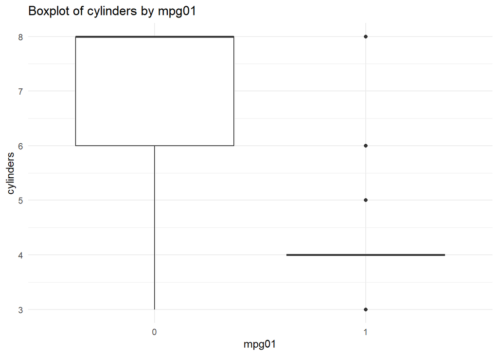

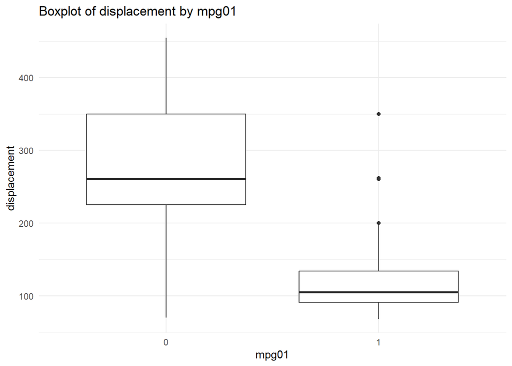

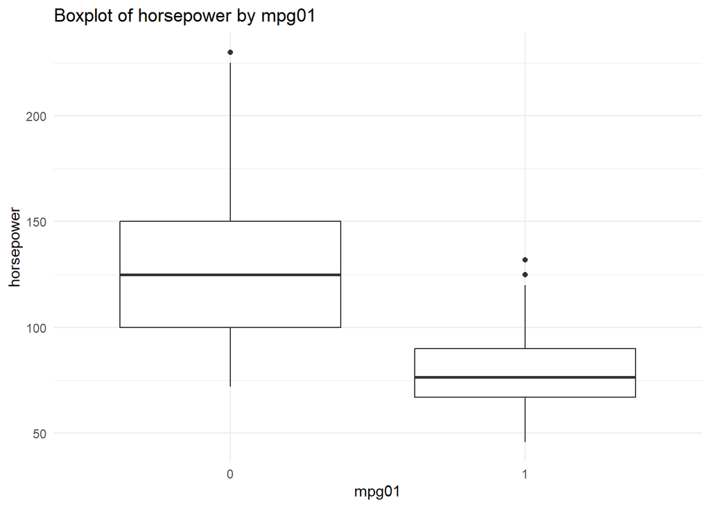

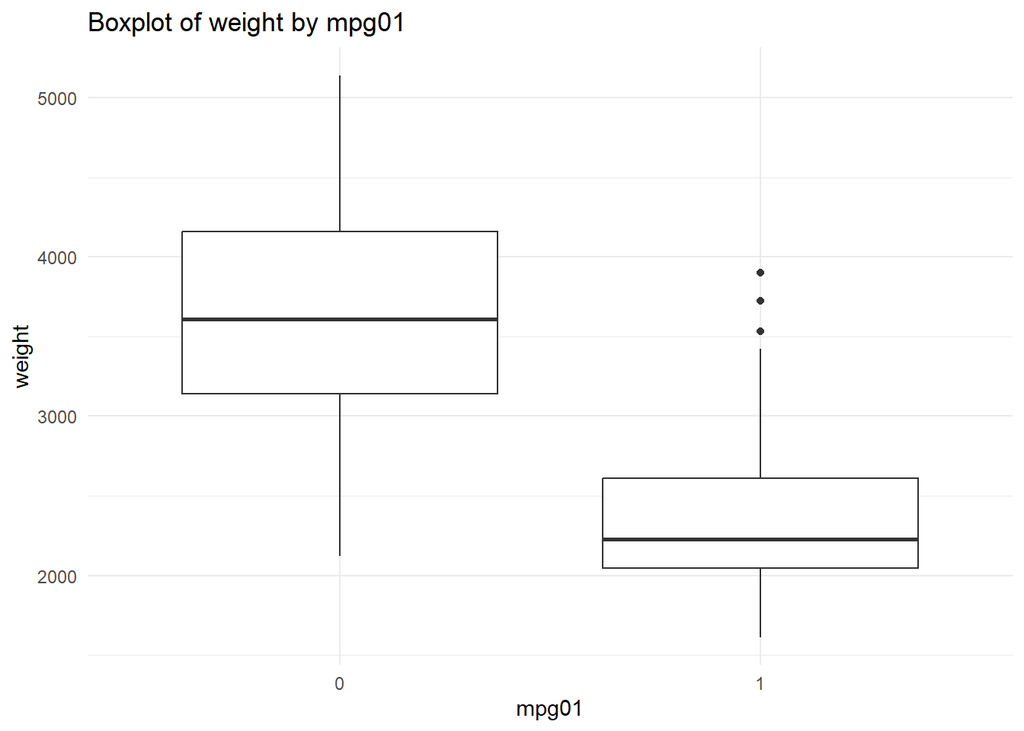

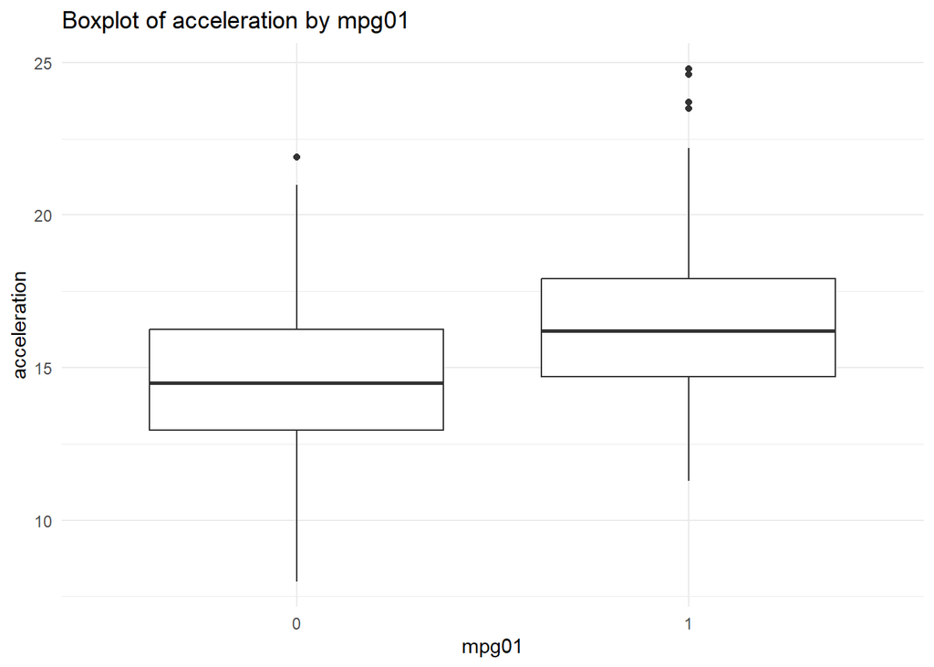

```
Findings:
1)The above graphs indicate that cars with low fuel efficiency which is mpg01 = 0 are characterized by having more cylinders, higher displacement, and greater horsepower.
2)Cars with high-efficiency or mpg01 = 1 are likely to have fewer cylinders, smaller displacement and lower horsepower which suggests that higher fuel efficiency is generally associated with smaller and less powerful engines.
3) We can also conclude that cars with higher fuel efficiency are usually lighter and have a slight tendency towards higher acceleration compared to cars with lower fuel efficiency.
```

```r
features <- c("cylinders", "displacement", "horsepower", "weight", "acceleration")
for (feature in features) {
  p <-ggplot(Auto, aes(x = factor(mpg01), y = .data[[feature]])) +
    geom_boxplot() +labs(x = "mpg01", y = feature, title = paste("Boxplot of", feature, "by mpg01")) +
    theme_minimal()
  print(p)
}
```

(3).[2 points] Split the data into a training set and a test set.

```
Answer:
```

```r
set.seed(123)
train_proportion <- 0.8

train_size <- floor(train_proportion * nrow(Auto))
train_indices <- sample(seq_len(nrow(Auto)), size = train_size)
trainset <- Auto[train_indices, ]
testset<- Auto[-train_indices, ]

cat("Training Set Dimensions are:", dim(trainset), "\n")
```

```
## Training Set Dimensions are: 313 10
```

```r
cat("Test Set Dimensions are", dim(testset), "\n")
```

```
## Test Set Dimensions are 79 10
```

(4).[3 points] Perform LDA on the training data in order to predict `mpg01` using the variables that seemed most associated with `mpg01` in (2). What is the test error of the model obtained?

```
Answer:
```

```r
lda_model <- lda(mpg01 ~ weight + displacement + horsepower + cylinders, data = trainset)
print(lda_model)
```

```
## Call:
## lda(mpg01 ~ weight + displacement + horsepower + cylinders, data = trainset)
##
## Prior probabilities of groups:
##         0         1
## 0.4920128 0.5079872
##
## Group means:
##     weight displacement horsepower cylinders
## 0 3634.422      274.987  131.45455  6.798701
## 1 2323.302      114.283   78.45912  4.163522
##
## Coefficients of linear discriminants:
##                       LD1
## weight       -0.001000777
## displacement -0.001033481
## horsepower    0.003881148
## cylinders    -0.501316051
```

```r
lda_predictions <- predict(lda_model, testset)$class
test_error <- mean(lda_predictions != testset$mpg01)

cat("Test Error Rate for LDA model is:",test_error, "\n")
```

```
## Test Error Rate for LDA model is: 0.1392405
```

(5).[3 points] Perform QDA on the training data in order to predict `mpg01` using the variables that seemed most associated with `mpg01` in (2). What is the test error of the model obtained?

```
Answer:
```

```r
qda_model <- qda(mpg01 ~ weight + displacement + horsepower + cylinders, data = trainset)
print(qda_model)
```

```
## Call:
## qda(mpg01 ~ weight + displacement + horsepower + cylinders, data = trainset)
##
## Prior probabilities of groups:
##         0         1
## 0.4920128 0.5079872
##
## Group means:
##     weight displacement horsepower cylinders
## 0 3634.422      274.987  131.45455  6.798701
## 1 2323.302      114.283   78.45912  4.163522
```

```r
qda_predictions <- predict(qda_model, testset)$class
test_error_qda <- mean(qda_predictions != testset$mpg01)

cat("Test Error Rate for the QDA:", test_error_qda, "\n")
```

```
## Test Error Rate for the QDA: 0.1139241
```

(6). [3 points] Perform logistic regression on the training data in order to predict `mpg01` using the variables that seemed most associated with `mpg01` in (2). What is the test error of the model obtained?

```
Answer:
```

```r
logistic_model <- glm(mpg01 ~ weight + displacement + horsepower + cylinders, data = trainset, family = binomial)
summary(logistic_model)
```

```
##
## Call:
## glm(formula = mpg01 ~ weight + displacement + horsepower + cylinders,
##     family = binomial, data = trainset)
##
## Coefficients:
##                Estimate Std. Error z value Pr(>|z|)
## (Intercept)  13.2775482  2.1223034   6.256 3.94e-10 ***
## weight       -0.0021961  0.0008331  -2.636  0.00838 **
## displacement -0.0151889  0.0093531  -1.624  0.10439
## horsepower   -0.0514584  0.0168285  -3.058  0.00223 **
## cylinders     0.0868500  0.3902663   0.223  0.82389
## ---
## Signif. codes:  0 '***' 0.001 '**' 0.01 '*' 0.05 '.' 0.1 ' ' 1
##
## (Dispersion parameter for binomial family taken to be 1)
##
##     Null deviance: 433.83  on 312  degrees of freedom
## Residual deviance: 149.26  on 308  degrees of freedom
## AIC: 159.26
##
## Number of Fisher Scoring iterations: 7
```

```r
logit_probabilities <- predict(logistic_model, testset, type = "response")
logit_predictions <- ifelse(logit_probabilities > 0.5, 1, 0)

testerror_logit <- mean(logit_predictions != testset$mpg01)
cat("Test Error Rate for The Logistic Regression model:", testerror_logit, "\n")
```

```
## Test Error Rate for The Logistic Regression model: 0.1518987
```

(7). [3 points] Perform naive Bayes on the training data in order to predict `mpg01` using the variables that seemed most associated with `mpg01` in (2). What is the test error of the model obtained?

```
Answer:
```

```r
library(e1071)
naive_bayes_model <- naiveBayes(mpg01 ~ weight + displacement + horsepower + cylinders, data = trainset)
print(naive_bayes_model)
```

```
##
## Naive Bayes Classifier for Discrete Predictors
##
## Call:
## naiveBayes.default(x = X, y = Y, laplace = laplace)
##
## A-priori probabilities:
## Y
##         0         1
## 0.4920128 0.5079872
##
## Conditional probabilities:
##    weight
## Y       [,1]     [,2]
##   0 3634.422 673.7928
##   1 2323.302 381.7963
##
##    displacement
## Y      [,1]     [,2]
##   0 274.987 90.03674
##   1 114.283 35.65040
##
##    horsepower
## Y        [,1]     [,2]
##   0 131.45455 37.57834
##   1  78.45912 15.40826
##
##    cylinders
## Y       [,1]      [,2]
##   0 6.798701 1.4020520
##   1 4.163522 0.6450808
```

```r
nb_predictions <- predict(naive_bayes_model, testset)
test_error_nb <- mean(nb_predictions != testset$mpg01)
cat("Test Error Rate for Naive Bayes model:", test_error_nb, "\n")
```

```
## Test Error Rate for Naive Bayes model: 0.1265823
```

(8). [5 points] Perform KNN on the training data in order to predict `mpg01` using the variables that seemed most associated with `mpg01` in (2). What is the test error of the model obtained? Which value of K seems to perform the best on this data set?

```
Answer:
```

```r
predictors <- c("weight", "displacement", "horsepower", "cylinders")
train_X <- trainset[, predictors]
test_X<- testset[, predictors]
train_y <- trainset$mpg01
test_y <- testset$mpg01

k_values <- c(1, 3, 5, 7, 9)
test_errors <- numeric(length(k_values))

for (i in seq_along(k_values)) {
  k <- k_values[i]
  knn_predictions <- knn(train = train_X, test = test_X, cl = train_y, k = k)
  test_errors[i] <- mean(knn_predictions != test_y)
  cat("The Test Error for K =", k, ":", test_errors[i], "\n")
}
```

```
## The Test Error for K = 1 : 0.2025316
## The Test Error for K = 3 : 0.1518987
## The Test Error for K = 5 : 0.1518987
## The Test Error for K = 7 : 0.164557
## The Test Error for K = 9 : 0.1265823
```

```r
best_k_value <- k_values[which.min(test_errors)]
best_test_error <- min(test_errors)

cat("Best K:", best_k_value, "\n")
```

```
## Best K: 9
```

```r
cat("Lowest Test Error Rate:", best_test_error, "\n")
```

```
## Lowest Test Error Rate: 0.1265823
```

(9).[3 points] Compare the above models, which models do you think is the best, why?

```
Answer:
```

[output not shown]